# Lab 2

Jamaal Green

4/11/2017

Data file:

- californiatod.csv
- R markdown

# Getting Started: Reviewing basic data structure and conventions

Open RStudio, set your working directory using either **setwd()** or using RStudio’s mune click “Session” -> “Set Working Directory” -> “Choose Directory”

Download the californiatod csv and save it to your working directory. Import and name the csv “californiatod”. To remind yourself about the variable types of your dataframe use the **str()** function. Type str(**“name of df”**) and basic information regarding variable will be displayed. Remember that we have both categorical variables (called “factors” in R) and continuous/interval variables.

# Construct Descriptive Statistics

The methods for analyzing your variables depend upon their variable type.

## Categorical/Nominal

*Create a Frequency Table*

Frequency tables help us to understand basic count information of our categorical variables. To create one use the **table()** function.

*Create a Cross-Tabulation Table*

In order to see how rail type breaks down by region we will create a cross-tabulation table (crosstab for short) for the two categorical variables (railtype and region). Which region has the most light rail TOD sites in this dataset?

```r
if(!require(pacman)){install.packages("pacman"); library(pacman)}
p_load(readr, psych, dplyr, stargazer, scales, ggplot2,  vcd)

californiatod <- read_csv("californiatod.csv")

table(californiatod$railtype, californiatod$region)
```

```
##
##                          Bay Area LA Sacramento SD
##   Heavy or commuter rail       12  4          0  1
##   Light rail                    1  2          2  4
```

*Create a mosaic plot*

A mosaic plot help you to visualize the relationship between categorical variables. In order to create a mosaic plaot we will use the **vcd** package, a package used for categorical data analysis.

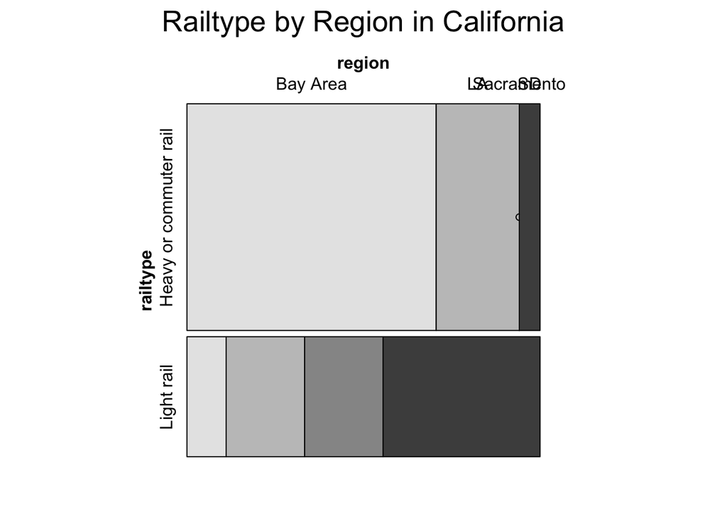

```r
mosaic(region ~ railtype, californiatod, main = "Railtype by Region in California")
```

*Continuous (ordinal or Interval-Ratio) variables*

In order to produce summary statistics for continuous variables we will use the base R **summary()** function. And to calculate the standard deviation we will use the base R **sd()** function.

```r
summary(californiatod$density)
```

```
##    Min. 1st Qu.  Median    Mean 3rd Qu.    Max.
##   1.720   3.225   4.335   5.360   5.135  14.850
```

```r
sd(californiatod$density)
```

```
## [1] 3.531352
```

An alternative way that will give us summary statistics for all of the continuous variables in our dataframe in a neat table is to use the *stargazer* package.

Compare the mean density to the minimum and maximum values for transit usage. Is the mean closer to the minimum or the maximum? How does it compare to the median? What does this tell us?

```r
#Note, the type = text attribute allows you to output tables in different formats
#for this lab I am outputting to an html format for display purposes.
#For your lab choose type = text for readability

stargazer(as.data.frame(californiatod), type = "html")
```

| Statistic | N | Mean | St. Dev. | Min | Max |
| --- | --- | --- | --- | --- | --- |
| transit | 26 | 0.253 | 0.190 | 0.000 | 0.643 |
| density | 26 | 5.360 | 3.531 | 1.720 | 14.850 |
| houseval | 26 | 282,154.700 | 163,092.200 | 89,045.740 | 779,792.000 |

Let’s explore further. This time we will include the skewness and kurtosis of our summary stats (we will use the *psych* package for this)

```r
#the psych package gives us an even broader array of summary functions

describe(californiatod)
```

```
##           vars  n      mean        sd    median   trimmed      mad
## name*        1 26       NaN        NA        NA       NaN       NA
## region*      2 26       NaN        NA        NA       NaN       NA
## transit      3 26      0.25      0.19      0.19      0.24     0.19
## density      4 26      5.36      3.53      4.34      4.81     1.62
## houseval     5 26 282154.69 163092.19 258209.17 258284.88 96930.33
## railtype*    6 26       NaN        NA        NA       NaN       NA
##                min       max     range skew kurtosis       se
## name*          Inf      -Inf      -Inf   NA       NA       NA
## region*        Inf      -Inf      -Inf   NA       NA       NA
## transit       0.00      0.64      0.64 0.54    -0.96     0.04
## density       1.72     14.85     13.13 1.53     1.38     0.69
## houseval  89045.74 779791.98 690746.24 1.57     2.08 31985.01
## railtype*      Inf      -Inf      -Inf   NA       NA       NA
```

## Histograms

As with all things in R there are multiple ways to get to the same spot. We will make a histogram in order to look at the distribution of transit usage frequency using both base R and the *ggplot2* package.

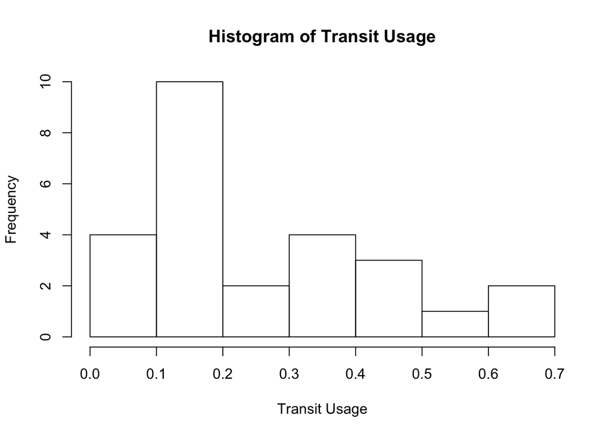

```r
hist(californiatod$transit, main = "Histogram of Transit Usage", xlab = "Transit Usage")
```

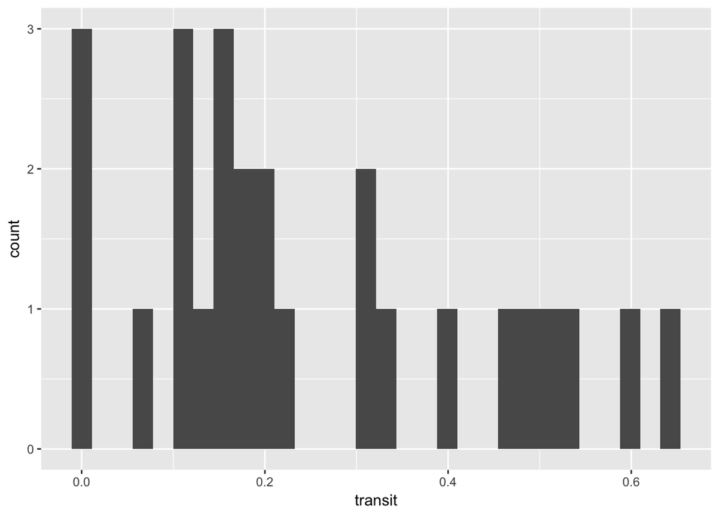

```r
#the ggplot way

p1 <- ggplot(californiatod, aes(x = transit))
p1 + geom_histogram()
```

## Scatterplots

A scatterplot will show us the relationship between two continuous variables. Again we will use a base R and ggplot approach.

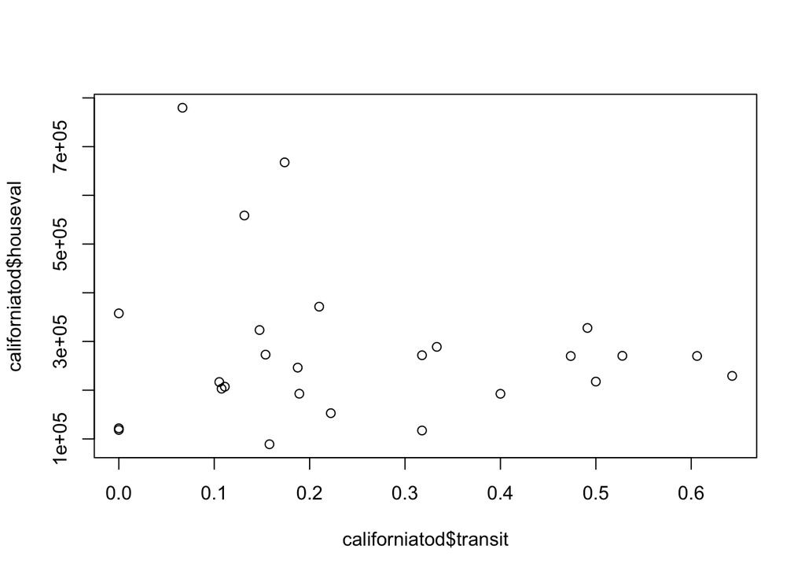

```r
#comparing transit usage and houseval

plot(californiatod$transit, californiatod$houseval)
```

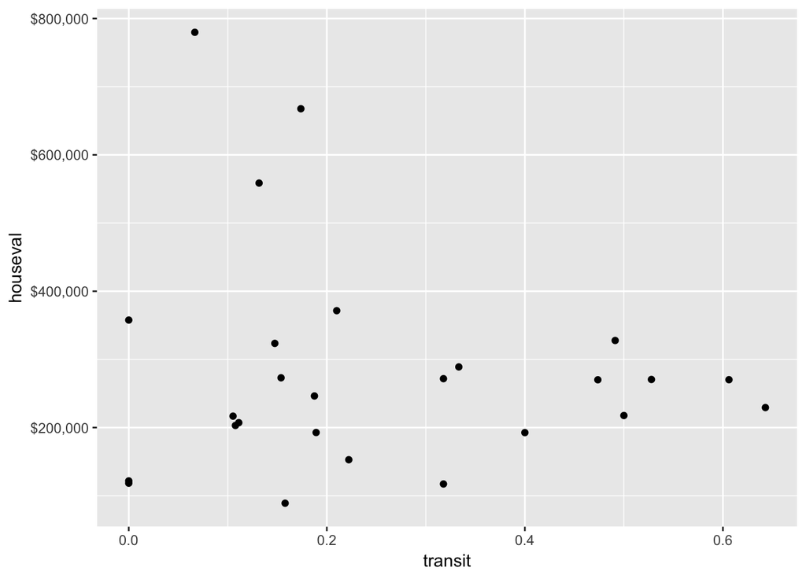

```r
#we will use the labeling features from the scales package in order to label our
# y axis in dollars

p2 <- ggplot(californiatod, aes(x = transit, y = houseval))
p2 + geom_point() + scale_y_continuous(labels = scales::dollar)
```

## Different Tables of Statistics

**Create a Two-Way Crosstab**

Run a two-way cross-tabulation for each of the following questions:

- Does transit usage vary by region?
- Does transit usage vary by rail type?

```r
#the base R two-way crosstab

table(californiatod$region, californiatod$railtype)
```

```
##
##              Heavy or commuter rail Light rail
##   Bay Area                       12          1
##   LA                              4          2
##   Sacramento                      0          2
##   SD                              1          4
```

Now we will do something a bit more complicated. We will create a new two-way crosstab like you did above but now let’s include the mean of a continuous third variable. This sounds complex, but we shall approach it in a straightforward way using the *dplyr* package.

```r
#the dplyr way
#we will first calculate our cross tabs and then the mean of transit usage

californiatod %>% group_by(region, railtype) %>%
  summarise(RailType = n(), AvgTransit = mean(transit))
```

```
## Source: local data frame [7 x 4]
## Groups: region [?]
##
##       region               railtype RailType AvgTransit
##        <chr>                  <chr>    <int>      <dbl>
## 1   Bay Area Heavy or commuter rail       12  0.3732583
## 2   Bay Area             Light rail        1  0.0000000
## 3         LA Heavy or commuter rail        4  0.2090250
## 4         LA             Light rail        2  0.1589000
## 5 Sacramento             Light rail        2  0.1900500
## 6         SD Heavy or commuter rail        1  0.1538000
## 7         SD             Light rail        4  0.1020000
```

The *dplyr* package is designed to perform table operations on dataframes for multiple kinds of data manipulation. The preceding syntax told R to take our californiatod dataframe, group by the variables for region and railtype, and the calculate the mean transit usage from there. This is similar to the kind of pivot table operations once can do in excel.

# Other Usefil Tidbits

*Script Window*

If you click the button with the little green + sign in the upper left corner of your screen you will open up a menu. Click “R script” and this will open a new window in your Rstudio. This is your Rscript file. R scripts are text files that hold our R code. You can type commands into them and press the Run button at the top of the window to run the **entire** script. If you simply scroll to the end of the line you just finished typing and hit “CTRL+r” Rstudio will execute that line. Additionally, you can highlight multiple lines of your code and type “CTRL+Enter” and it will run your highlighted selection.